# hw2

Author

Andre Gala-Garza

Published

February 26, 2026

**Disclaimer:** Generative AI was used to assist with templating and writing code in this assignment; however, this code was checked manually and edited by hand to ensure accuracy.

**Source:** OpenAI. (2026). *ChatGPT (GPT-5.2 Thinking)* [Large language model]. https://chatgpt.com/.

# 1. Data Wrangling

## (i) Merge datasets into one

```r
library("dplyr")
library("ggplot2")

# load data
chs_individual <- read.csv("chs_individual.csv")
chs_regional   <- read.csv("chs_regional.csv")
```

```r
dim(chs_individual)
```

```
[1] 1200   23
```

```r
head(chs_individual)
```

```
  sid  townname male race hispanic    agepft height weight      bmi asthma
1   1 Lancaster    1    W        0 10.154689    123     54 16.22411      0
2   2 Lancaster    1    W        0 10.461328    145     77 16.64685      0
3   6 Lancaster    0    B        0 10.097194    145    143 30.91558      0
4   7 Lancaster    0    O        0 10.746064    156     72 13.44809      0
5   8 Lancaster    0    W        1  9.782341    132     61 15.91326      0
6  10 Lancaster    1    O        1        NA     NA     NA       NA      0
  active_asthma father_asthma mother_asthma wheeze hayfever allergy educ_parent
1             0             0             0      0        0       0           3
2             0             0             0      1        0       0           5
3             0             0             0      0        1       0           2
4             0            NA             0      1        0       0           2
5             0             1             0      1        1       1           3
6             1             1             0      0        0       0           1
  smoke pets gasstove      fev      fvc     mmef
1     0    1        1 1650.254 1800.005 2537.777
2     0    1        0 2273.129 2721.111 2365.745
3     0    0        1 2011.653 2257.244 1818.973
4     1    1        1 1643.092 2060.526 1462.500
5     0    1        0 1651.974 1996.382 1606.579
6     0    1        1       NA       NA       NA
```

```r
dim(chs_regional)
```

```
[1] 12 27
```

```r
head(chs_regional)
```

```
       townname pm25_mass pm25_so4 pm25_no3 pm25_nh4 pm25_oc pm25_ec pm25_om
1        Alpine      8.74     1.73     1.59     0.88    2.54    0.48    3.04
2 Lake Elsinore     12.35     1.90     2.98     1.36    3.64    0.62    4.36
3  Lake Gregory      7.66     1.07     2.07     0.91    2.46    0.40    2.96
4     Lancaster      8.50     0.91     1.87     0.78    4.43    0.55    5.32
5        Lompoc      5.96     1.08     0.73     0.41    1.45    0.13    1.74
6    Long Beach     19.12     3.23     6.22     2.57    5.21    1.36    6.25
  pm10_oc pm10_ec pm10_tc formic acetic  hcl hno3 o3_max o3106 o3_24   no2
1    3.25    0.49    3.75   1.03   2.49 0.41 1.98  65.82 55.05 41.23 12.18
2    4.66    0.63    5.29   1.18   3.56 0.46 2.63  66.70 54.42 32.23 17.03
3    3.16    0.41    3.57   0.66   2.36 0.28 2.28  84.44 67.01 57.76  7.62
4    5.68    0.56    8.61   0.88   2.88 0.22 1.80  54.81 43.88 32.86 15.77
5    1.86    0.14    1.99   0.34   0.75 0.33 0.43  43.85 37.74 28.37  4.60
6    6.68    1.39    8.07   1.57   2.94 0.73 2.67  39.44 28.22 18.22 33.11
   pm10 no_24hr pm2_5_fr iacid oacid total_acids       lon      lat
1 24.73    2.48    10.28  2.39  3.52        5.50 -116.7664 32.83505
2 34.25    7.07    14.53  3.09  4.74        7.37 -117.3273 33.66808
3 20.05      NA     9.01  2.56  3.02        5.30 -117.2752 34.24290
4 25.04   12.68       NA  2.02  3.76        5.56 -118.1542 34.68678
5 18.40    2.05       NA  0.76  1.09        1.52 -120.4579 34.63915
6 38.41   36.76    22.23  3.40  4.51        7.18 -118.1937 33.77005
```

```r
names(chs_individual)
```

```
 [1] "sid"           "townname"      "male"          "race"
 [5] "hispanic"      "agepft"        "height"        "weight"
 [9] "bmi"           "asthma"        "active_asthma" "father_asthma"
[13] "mother_asthma" "wheeze"        "hayfever"      "allergy"
[17] "educ_parent"   "smoke"         "pets"          "gasstove"
[21] "fev"           "fvc"           "mmef"
```

```r
names(chs_regional)
```

```
 [1] "townname"    "pm25_mass"   "pm25_so4"    "pm25_no3"    "pm25_nh4"
 [6] "pm25_oc"     "pm25_ec"     "pm25_om"     "pm10_oc"     "pm10_ec"
[11] "pm10_tc"     "formic"      "acetic"      "hcl"         "hno3"
[16] "o3_max"      "o3106"       "o3_24"       "no2"         "pm10"
[21] "no_24hr"     "pm2_5_fr"    "iacid"       "oacid"       "total_acids"
[26] "lon"         "lat"
```

```r
library(dplyr)

# Check whether townname is unique in regional data
chs_regional %>%
  count(townname, name = "n") %>%
  arrange(desc(n)) %>%
  head()
```

```
       townname n
1        Alpine 1
2    Atascadero 1
3 Lake Elsinore 1
4  Lake Gregory 1
5     Lancaster 1
6        Lompoc 1
```

```r
# Merge (adds regional exposures to each child)
chs <- chs_individual %>%
  left_join(chs_regional, by = "townname")

# Row count should match individual dataset if regional townname is unique
nrow(chs_individual)
```

```
[1] 1200
```

```r
# Check for duplicate rows after merge (should be the same as nrow(chs))
nrow(chs)
```

```
[1] 1200
```

```r
nrow(distinct(chs))
```

```
[1] 1200
```

```r
# Check missingness
cat("Rows, cols:\n"); print(dim(chs))
```

```
Rows, cols:
```

```
[1] 1200   49
```

```r
cat("\nFirst 6 rows:\n"); print(head(chs))
```

```
First 6 rows:
```

```
  sid  townname male race hispanic    agepft height weight      bmi asthma
1   1 Lancaster    1    W        0 10.154689    123     54 16.22411      0
2   2 Lancaster    1    W        0 10.461328    145     77 16.64685      0
3   6 Lancaster    0    B        0 10.097194    145    143 30.91558      0
4   7 Lancaster    0    O        0 10.746064    156     72 13.44809      0
5   8 Lancaster    0    W        1  9.782341    132     61 15.91326      0
6  10 Lancaster    1    O        1        NA     NA     NA       NA      0
  active_asthma father_asthma mother_asthma wheeze hayfever allergy educ_parent
1             0             0             0      0        0       0           3
2             0             0             0      1        0       0           5
3             0             0             0      0        1       0           2
4             0            NA             0      1        0       0           2
5             0             1             0      1        1       1           3
6             1             1             0      0        0       0           1
  smoke pets gasstove      fev      fvc     mmef pm25_mass pm25_so4 pm25_no3
```

[output cut: 27 more lines]

```r
na_counts <- sapply(chs, function(x) sum(is.na(x)))
na_counts <- sort(na_counts[na_counts > 0], decreasing = TRUE)

cat("\nVariables with missing values (count):\n")
```

```
Variables with missing values (count):
```

```r
print(na_counts)
```

```
     pm2_5_fr      hayfever father_asthma          mmef       no_24hr
          300           118           106           106           100
          fvc           fev        agepft        height        weight
           97            95            89            89            89
          bmi        wheeze   educ_parent       allergy mother_asthma
           89            71            64            63            56
        smoke      gasstove        asthma
           40            33            31
```

```r
cat("\nTotal missing values:\n")
```

```
Total missing values:
```

```r
print(sum(is.na(chs)))
```

```
[1] 1636
```

```r
# ---- imputation helpers ----
Mode <- function(x) {
  x <- x[!is.na(x)]
  if (length(x) == 0) return(NA)
  tab <- table(x)
  names(tab)[which.max(tab)]
}

# Identify variable types
num_vars <- names(chs)[sapply(chs, is.numeric)]
cat_vars <- names(chs)[sapply(chs, function(x) is.character(x) || is.factor(x) || is.logical(x))]

# Don't try to impute the grouping variables with themselves
num_vars <- setdiff(num_vars, c("male", "hispanic"))
cat_vars <- setdiff(cat_vars, c("male", "hispanic"))

cat("\nNumeric variables to mean-impute within (male,hispanic):\n")
```

```
Numeric variables to mean-impute within (male,hispanic):
```

```r
print(num_vars)
```

```
 [1] "sid"           "agepft"        "height"        "weight"
 [5] "bmi"           "asthma"        "active_asthma" "father_asthma"
 [9] "mother_asthma" "wheeze"        "hayfever"      "allergy"
[13] "educ_parent"   "smoke"         "pets"          "gasstove"
[17] "fev"           "fvc"           "mmef"          "pm25_mass"
[21] "pm25_so4"      "pm25_no3"      "pm25_nh4"      "pm25_oc"
[25] "pm25_ec"       "pm25_om"       "pm10_oc"       "pm10_ec"
[29] "pm10_tc"       "formic"        "acetic"        "hcl"
[33] "hno3"          "o3_max"        "o3106"         "o3_24"
[37] "no2"           "pm10"          "no_24hr"       "pm2_5_fr"
[41] "iacid"         "oacid"         "total_acids"   "lon"
[45] "lat"
```

```r
cat("\nCategorical variables to mode-impute within (male,hispanic):\n")
```

```
Categorical variables to mode-impute within (male,hispanic):
```

```r
print(cat_vars)
```

```
[1] "townname" "race"
```

```r
# Groupwise imputation: mean for numeric, mode for categorical
chs_imp <- chs %>%
  group_by(male, hispanic) %>%
  mutate(
    across(all_of(num_vars),
           ~ ifelse(is.na(.x), mean(.x, na.rm = TRUE), .x)),
    across(all_of(cat_vars),
           ~ {
             m <- Mode(.x)
             ifelse(is.na(.x), m, .x)
           })
  ) %>%
  ungroup()

# if some groups had all-NA for a variable, mean(.x, na.rm=TRUE) returns NaN
# and Mode() returns NA. Replace any remaining NaN with NA to make it obvious.
chs_imp <- chs_imp %>%
  mutate(across(where(is.numeric), ~ ifelse(is.nan(.x), NA, .x)))

# confirm missingness after imputation
na_counts_after <- sapply(chs_imp, function(x) sum(is.na(x)))
na_counts_after <- sort(na_counts_after[na_counts_after > 0], decreasing = TRUE)

cat("\nRemaining variables with missing values after imputation (count):\n")
```

```
Remaining variables with missing values after imputation (count):
```

```r
print(na_counts_after)
```

```
named integer(0)
```

```r
cat("\nTotal missing values after imputation:\n")
```

```
Total missing values after imputation:
```

```r
print(sum(is.na(chs_imp)))
```

```
[1] 0
```

```r
cat("\nHead of imputed dataset:\n")
```

```
Head of imputed dataset:
```

```r
head(chs_imp)
```

```
# A tibble: 6 × 49
    sid townname   male race  hispanic agepft height weight   bmi asthma
  <int> <chr>     <int> <chr>    <int>  <dbl>  <dbl>  <dbl> <dbl>  <dbl>
1     1 Lancaster     1 W            0  10.2    123    54    16.2      0
2     2 Lancaster     1 W            0  10.5    145    77    16.6      0
3     6 Lancaster     0 B            0  10.1    145   143    30.9      0
4     7 Lancaster     0 O            0  10.7    156    72    13.4      0
5     8 Lancaster     0 W            1   9.78   132    61    15.9      0
6    10 Lancaster     1 O            1   9.97   139.   82.8  19.4      0
# ℹ 39 more variables: active_asthma <int>, father_asthma <dbl>,
#   mother_asthma <dbl>, wheeze <dbl>, hayfever <dbl>, allergy <dbl>,
#   educ_parent <dbl>, smoke <dbl>, pets <int>, gasstove <dbl>, fev <dbl>,
#   fvc <dbl>, mmef <dbl>, pm25_mass <dbl>, pm25_so4 <dbl>, pm25_no3 <dbl>,
#   pm25_nh4 <dbl>, pm25_oc <dbl>, pm25_ec <dbl>, pm25_om <dbl>, pm10_oc <dbl>,
#   pm10_ec <dbl>, pm10_tc <dbl>, formic <dbl>, acetic <dbl>, hcl <dbl>,
#   hno3 <dbl>, o3_max <dbl>, o3106 <dbl>, o3_24 <dbl>, no2 <dbl>, …
```

## (ii) Create obesity level categorical variable

```r
names(chs_imp)
```

```
 [1] "sid"           "townname"      "male"          "race"
 [5] "hispanic"      "agepft"        "height"        "weight"
 [9] "bmi"           "asthma"        "active_asthma" "father_asthma"
[13] "mother_asthma" "wheeze"        "hayfever"      "allergy"
[17] "educ_parent"   "smoke"         "pets"          "gasstove"
[21] "fev"           "fvc"           "mmef"          "pm25_mass"
[25] "pm25_so4"      "pm25_no3"      "pm25_nh4"      "pm25_oc"
[29] "pm25_ec"       "pm25_om"       "pm10_oc"       "pm10_ec"
[33] "pm10_tc"       "formic"        "acetic"        "hcl"
[37] "hno3"          "o3_max"        "o3106"         "o3_24"
[41] "no2"           "pm10"          "no_24hr"       "pm2_5_fr"
[45] "iacid"         "oacid"         "total_acids"   "lon"
[49] "lat"
```

```r
bmi_var <- "bmi"

chs_imp <- chs_imp %>%
  mutate(
    obesity_level = case_when(
      .data[[bmi_var]] < 14                       ~ "underweight",
      .data[[bmi_var]] >= 14 & .data[[bmi_var]] <= 22 ~ "normal",
      .data[[bmi_var]] > 22  & .data[[bmi_var]] <= 24 ~ "overweight",
      .data[[bmi_var]] > 24                       ~ "obese",
      TRUE                                        ~ NA_character_
    ),
    obesity_level = factor(obesity_level,
                           levels = c("underweight", "normal", "overweight", "obese"))
  )

head(chs_imp %>% select(all_of(bmi_var), obesity_level))
```

```
# A tibble: 6 × 2
    bmi obesity_level
  <dbl> <fct>
1  16.2 normal
2  16.6 normal
3  30.9 obese
4  13.4 underweight
5  15.9 normal
6  19.4 normal
```

```r
# Summary table to verify coding
obesity_check <- chs_imp %>%
  group_by(obesity_level) %>%
  summarise(
    min_BMI = min(.data[[bmi_var]], na.rm = TRUE),
    max_BMI = max(.data[[bmi_var]], na.rm = TRUE),
    n = n(),
    .groups = "drop"
  )

obesity_check
```

```
# A tibble: 4 × 4
  obesity_level min_BMI max_BMI     n
  <fct>           <dbl>   <dbl> <int>
1 underweight      11.3    14.0    35
2 normal           14.0    22.0   975
3 overweight       22.0    24.0    87
4 obese            24.0    41.3   103
```

## (iii) Create smoke/gas exposure categorical variable

```r
unique(chs_imp$gasstove)
```

```
[1] 1.0000000 0.0000000 0.8156863 0.8218623 0.7798742 0.7291066
```

```r
unique(chs_imp$smoke)
```

```
[1] 0.0000000 1.0000000 0.1535270 0.1949686 0.1501976 0.1522989
```

Note that for some of the records in the dataset, the values of “gasstove” and “smoke” were not binary (i.e. either 0 or 1). For these cases, the “gasstove” and “smoke” categorical variables were rounded to either 0 or 1 depending on whether the original value was greater than or equal to 0.5.

```r
library(dplyr)

shs_var <- "smoke"
gas_var <- "gasstove"

chs_imp <- chs_imp %>%
  mutate(
    shs_bin = case_when(
      is.na(.data[[shs_var]]) ~ NA_real_,
      .data[[shs_var]] %in% c(1, "1", "Y", "Yes", "YES", TRUE) ~ 1,
      .data[[shs_var]] %in% c(0, "0", "N", "No",  "NO",  FALSE) ~ 0,
      suppressWarnings(!is.na(as.numeric(as.character(.data[[shs_var]])))) ~
        if_else(
          as.numeric(as.character(.data[[shs_var]])) >= 0.5,
          1, 0
        ),
      TRUE ~ NA_real_
    ),
    gas_bin = case_when(
      is.na(.data[[gas_var]]) ~ NA_real_,
      .data[[gas_var]] %in% c(1, "1", "Y", "Yes", "YES", TRUE) ~ 1,
      .data[[gas_var]] %in% c(0, "0", "N", "No",  "NO",  FALSE) ~ 0,
      suppressWarnings(!is.na(as.numeric(as.character(.data[[gas_var]])))) ~
        if_else(
          as.numeric(as.character(.data[[gas_var]])) >= 0.5,
          1, 0
        ),
      TRUE ~ NA_real_
    ),
    smoke_gas_exposure = case_when(
      is.na(shs_bin) | is.na(gas_bin) ~ NA_character_,
      shs_bin == 0 & gas_bin == 0 ~ "neither",
      shs_bin == 1 & gas_bin == 0 ~ "secondhand_smoke_only",
      shs_bin == 0 & gas_bin == 1 ~ "gas_stove_only",
      shs_bin == 1 & gas_bin == 1 ~ "both",
      TRUE ~ NA_character_
    ),
    smoke_gas_exposure = factor(
      smoke_gas_exposure,
      levels = c("neither", "secondhand_smoke_only", "gas_stove_only", "both")
    )
  ) %>%
  select(-shs_bin, -gas_bin)

head(chs_imp %>% select(all_of(shs_var), all_of(gas_var), smoke_gas_exposure))
```

```
# A tibble: 6 × 3
  smoke gasstove smoke_gas_exposure
  <dbl>    <dbl> <fct>
1     0        1 gas_stove_only
2     0        0 neither
3     0        1 gas_stove_only
4     1        1 both
5     0        0 neither
6     0        1 gas_stove_only
```

```r
chs_imp %>%
  count(smoke_gas_exposure, name = "n")
```

```
# A tibble: 4 × 2
  smoke_gas_exposure        n
  <fct>                 <int>
1 neither                 219
2 secondhand_smoke_only    36
3 gas_stove_only          791
4 both                    154
```

## (iv) Make four summary tables

```r
library(dplyr)

# Asthma indicator: Forced expiratory volume in 1 second (ml)
names(chs_imp)
```

```
 [1] "sid"                "townname"           "male"
 [4] "race"               "hispanic"           "agepft"
 [7] "height"             "weight"             "bmi"
[10] "asthma"             "active_asthma"      "father_asthma"
[13] "mother_asthma"      "wheeze"             "hayfever"
[16] "allergy"            "educ_parent"        "smoke"
[19] "pets"               "gasstove"           "fev"
[22] "fvc"                "mmef"               "pm25_mass"
[25] "pm25_so4"           "pm25_no3"           "pm25_nh4"
[28] "pm25_oc"            "pm25_ec"            "pm25_om"
[31] "pm10_oc"            "pm10_ec"            "pm10_tc"
[34] "formic"             "acetic"             "hcl"
[37] "hno3"               "o3_max"             "o3106"
[40] "o3_24"              "no2"                "pm10"
[43] "no_24hr"            "pm2_5_fr"           "iacid"
[46] "oacid"              "total_acids"        "lon"
[49] "lat"                "obesity_level"      "smoke_gas_exposure"
```

```r
summary(chs_imp$fev)
```

```
   Min. 1st Qu.  Median    Mean 3rd Qu.    Max.
  984.8  1827.6  2016.4  2030.1  2223.6  3323.7
```

```r
# Make sex readable (male is 0/1)
chs_imp <- chs_imp %>%
  mutate(sex = factor(male, levels = c(0, 1), labels = c("female", "male")))

# Helper for mean/sd table
fev_summary <- function(df, group_var) {
  df %>%
    group_by(across(all_of(group_var))) %>%
    summarise(
      mean_fev = mean(fev, na.rm = TRUE),
      sd_fev   = sd(fev, na.rm = TRUE),
      n        = sum(!is.na(fev)),
      .groups  = "drop"
    ) %>%
    arrange(mean_fev)
}

# 1) By town
tab_town <- fev_summary(chs_imp, "townname")
tab_town
```

```
# A tibble: 12 × 4
   townname      mean_fev sd_fev     n
   <chr>            <dbl>  <dbl> <int>
 1 Mira Loma        1985.   325.   100
 2 Long Beach       1986.   319.   100
 3 Riverside        1990.   278.   100
 4 Lancaster        2003.   317.   100
 5 Upland           2024.   343.   100
 6 Santa Maria      2026.   312.   100
 7 San Dimas        2027.   319.   100
 8 Lompoc           2034.   351.   100
 9 Lake Elsinore    2039.   304.   100
10 Atascadero       2076.   324.   100
11 Lake Gregory     2085.   320.   100
12 Alpine           2087.   291.   100
```

```r
# 2) By sex
tab_sex <- fev_summary(chs_imp, "sex")
tab_sex
```

```
# A tibble: 2 × 4
  sex    mean_fev sd_fev     n
  <fct>     <dbl>  <dbl> <int>
1 female    1959.   312.   610
2 male      2104.   308.   590
```

```r
# 3) By obesity level
tab_obesity <- fev_summary(chs_imp, "obesity_level")
tab_obesity
```

```
# A tibble: 4 × 4
  obesity_level mean_fev sd_fev     n
  <fct>            <dbl>  <dbl> <int>
1 underweight      1698.   303.    35
2 normal           2000.   295.   975
3 overweight       2224.   317.    87
4 obese            2266.   325.   103
```

```r
# 4) By smoke_gas_exposure
tab_smoke_gas <- fev_summary(chs_imp, "smoke_gas_exposure")
tab_smoke_gas
```

```
# A tibble: 4 × 4
  smoke_gas_exposure    mean_fev sd_fev     n
  <fct>                    <dbl>  <dbl> <int>
1 gas_stove_only           2023.   319.   791
2 both                     2025.   301.   154
3 secondhand_smoke_only    2056.   296.    36
4 neither                  2057.   329.   219
```

In the sex table, we see that males have a noticeably higher FEV than females (2103 ml compared to 1958 ml), while the standard deviations are similar.

In the smoke/gas exposure table, we see that the means are very similar across groups relative to the standard deviation. Combined with the fact that some groups have very small sample sizes, this means that the group means can bounce around a lot just due to random sampling.

# 2. Exploratory Data Analysis (EDA)

## Steps 1-4

From the previous problem, we have already completed the first four steps on the EDA checklist:

1. Read in the data
2. Check the size of the data
3. Examine the variables and their types
4. Look at the top and bottom of the data

## Step 5: Visualize distributions of key variables

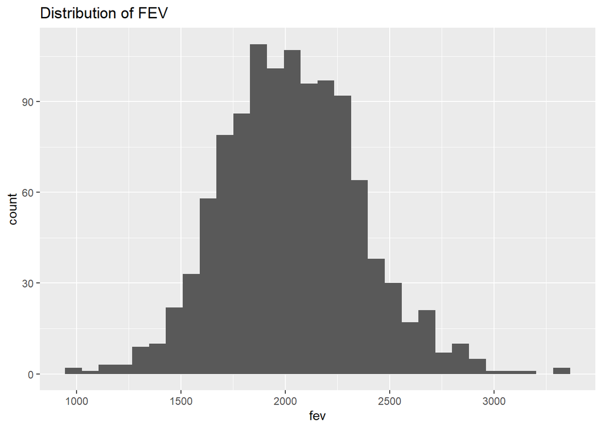

```r
# FEV
ggplot(chs, aes(x = fev)) + geom_histogram() + labs(title = "Distribution of FEV")
```

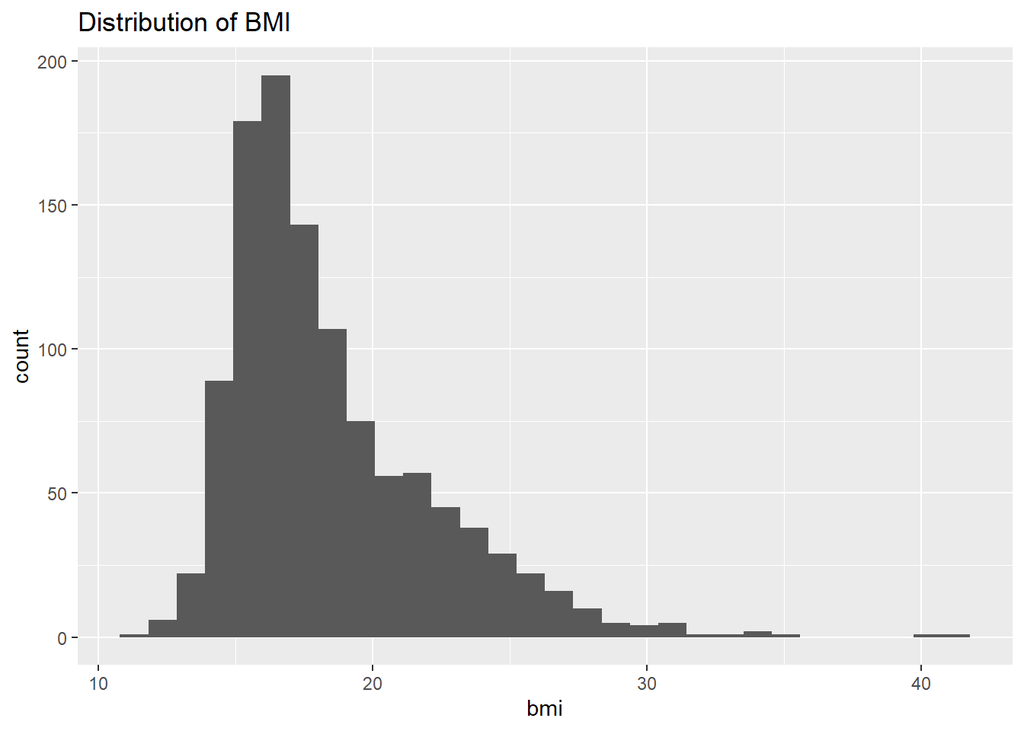

```r
# BMI
ggplot(chs, aes(x = bmi)) + geom_histogram() + labs(title = "Distribution of BMI")
```

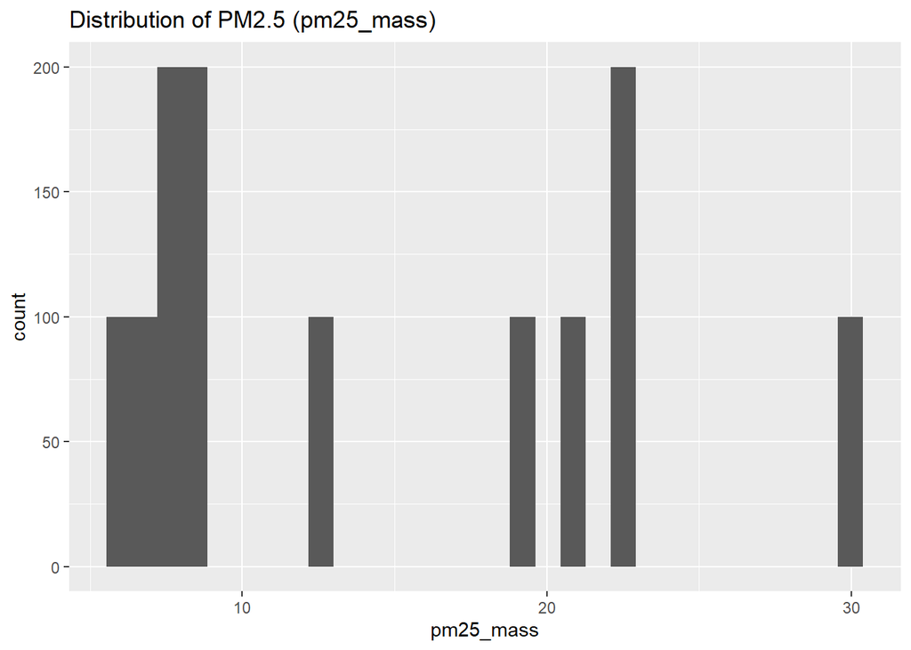

```r
# PM2.5 mass (community-level, repeats by child after merge)
ggplot(chs, aes(x = pm25_mass)) + geom_histogram() + labs(title = "Distribution of PM2.5 (pm25_mass)")
```

```r
# Smoke and gas stove
chs %>% count(smoke, useNA = "ifany")
```

```
  smoke useNA   n
1     0 ifany 970
2     1 ifany 190
3    NA ifany  40
```

```r
chs %>% count(gasstove, useNA = "ifany")
```

```
  gasstove useNA   n
1        0 ifany 255
2        1 ifany 912
3       NA ifany  33
```

From these histograms, we see that FEV follows a unimodal distribution centered around ~1900-2200 ml. It is roughly centered around the mean without being clearly left-tailed or right-tailed. The BMI distribution is clearly right-skewed, with most values clustered around ~14-20 followed by a long tail. Finally, the distribution of PM2.5 is not smooth, but instead contains one “spike” of either 100 or 200 records per community, since PM2.5 is measured at the community-level for 12 communities across southern California. In other words, the community-level analysis is the reason why the same measurements are being repeated either 100 or 200 times per community.

## Step 6: Check your expectations

```r
# FEV by sex (male=1 usually higher)
chs %>%
  mutate(sex = factor(male, levels = c(0,1), labels = c("female","male"))) %>%
  group_by(sex) %>%
  summarise(mean_fev = mean(fev, na.rm=TRUE), sd_fev = sd(fev, na.rm=TRUE), n = sum(!is.na(fev)))
```

```
# A tibble: 2 × 4
  sex    mean_fev sd_fev     n
  <fct>     <dbl>  <dbl> <int>
1 female    1959.   327.   554
2 male      2104.   318.   551
```

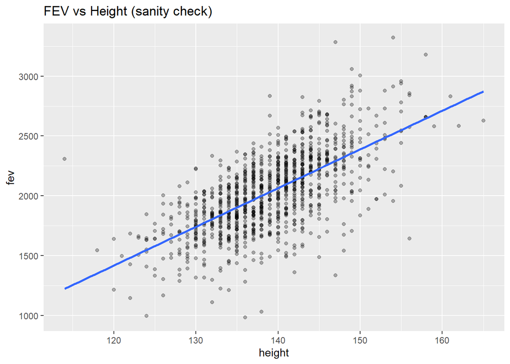

```r
# FEV vs height (should increase)
ggplot(chs, aes(x = height, y = fev)) +
  geom_point(alpha = 0.3) +
  geom_smooth(method = "lm", se = FALSE) +
  labs(title = "FEV vs Height (sanity check)")
```

## Steps 7 and 8: Validate with an external source + Formulate a (simple) question

We ask the following question: **Do the patterns match basic physiology?**

If FEV increases with height and is higher in males, then the data is internally consistent, since taller individuals tend to have larger lung capacities.

**Source:** Almaasfeh S, Abukonna A, Omer S, Osman H. Evaluation of Forced Expiratory Volume in One Second and Forced Vital Capacity from Age and Height for Pulmonary Function Test. West Afr J Med. 2023 Oct 31;40(10):1029-1034. PMID: 37906250.

## Steps 9 and 10: Try the easy solution first + Challenge your solution

### Q1: Association between BMI and FEV

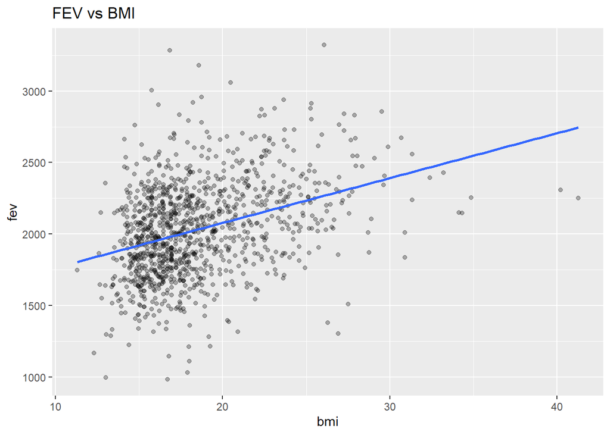

```r
df1 <- chs %>% filter(!is.na(bmi), !is.na(fev))

ggplot(df1, aes(x = bmi, y = fev)) +
  geom_point(alpha = 0.3) +
  geom_smooth(method = "lm", se = FALSE) +
  labs(title = "FEV vs BMI")
```

```r
m1_easy <- lm(fev ~ bmi, data = df1)
summary(m1_easy)
```

```
Call:
lm(formula = fev ~ bmi, data = df1)

Residuals:
   Min     1Q Median     3Q    Max
-991.5 -207.9   -5.4  200.9 1304.8

Coefficients:
            Estimate Std. Error t value Pr(>|t|)
(Intercept) 1450.760     46.497   31.20   <2e-16 ***
bmi           31.363      2.461   12.74   <2e-16 ***
---
Signif. codes:  0 '***' 0.001 '**' 0.01 '*' 0.05 '.' 0.1 ' ' 1

Residual standard error: 308.9 on 1103 degrees of freedom
Multiple R-squared:  0.1283,    Adjusted R-squared:  0.1275
F-statistic: 162.4 on 1 and 1103 DF,  p-value: < 2.2e-16
```

```r
# Challenge (adjust for sex/height/age)
m1_adj <- lm(fev ~ bmi + male + height + agepft, data = df1)
summary(m1_adj)
```

```
Call:
lm(formula = fev ~ bmi + male + height + agepft, data = df1)

Residuals:
   Min     1Q Median     3Q    Max
-970.0 -142.6   11.1  154.1  977.2

Coefficients:
              Estimate Std. Error t value Pr(>|t|)
(Intercept) -2370.4352   199.1887 -11.900  < 2e-16 ***
bmi            12.8052     2.0173   6.348 3.19e-10 ***
male          119.1256    14.3995   8.273 3.75e-16 ***
height         29.4857     1.1672  25.261  < 2e-16 ***
agepft          0.7716    17.3223   0.045    0.964
---
Signif. codes:  0 '***' 0.001 '**' 0.01 '*' 0.05 '.' 0.1 ' ' 1

Residual standard error: 237.3 on 1100 degrees of freedom
Multiple R-squared:  0.4867,    Adjusted R-squared:  0.4848
F-statistic: 260.8 on 4 and 1100 DF,  p-value: < 2.2e-16
```

In the easy (unadjusted) model, BMI is strongly and positively associated with lung function: each 1-unit increase in BMI corresponds to about 31.4 ml higher FEV (p < 2e−16), and BMI alone explains a modest share of FEV variability (R^2 ≈ 0.13). In the challenged (adjusted) model controlling for sex, height, and age, the BMI association shrinks substantially to about 12.8 ml higher FEV per BMI unit, but remains highly statistically significant (p ≈ 3.2e−10). This drop in the BMI coefficient suggests that a large part of the crude BMI–FEV relationship reflects body size/physiology captured by height and sex (both strongly predictive: ~+29.5 ml per height unit and ~+119 ml for males), rather than BMI alone.

After adjustment, the model’s explanatory power increases dramatically (R^2 ≈ 0.49), indicating that height and sex account for much more variation in FEV than BMI does; nonetheless, BMI still shows an independent positive association with FEV in this dataset, while age contributes little here (p ≈ 0.96).

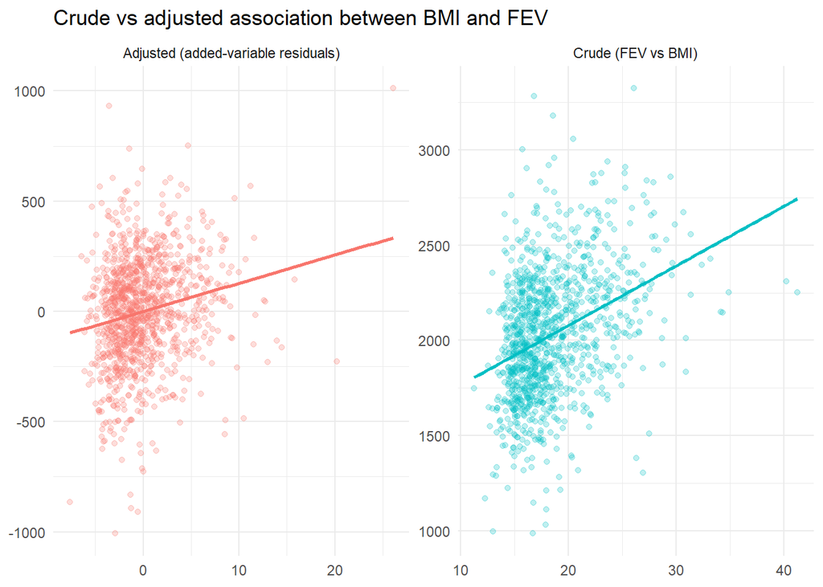

```r
df_plot <- df1 %>%
  mutate(
    bmi_resid = resid(lm(bmi ~ male + height + agepft, data = df1)),
    fev_resid = resid(lm(fev ~ male + height + agepft, data = df1))
  )

# Put both relationships in one panel by standardizing axes:
# - Crude: (bmi, fev)
# - Adjusted (AV): (bmi_resid, fev_resid)
long_plot <- bind_rows(
  df_plot %>%
    transmute(x = bmi, y = fev, type = "Crude (FEV vs BMI)"),
  df_plot %>%
    transmute(x = bmi_resid, y = fev_resid, type = "Adjusted (added-variable residuals)")
)

ggplot(long_plot, aes(x = x, y = y, color = type)) +
  geom_point(alpha = 0.25) +
  geom_smooth(method = "lm", se = FALSE, linewidth = 1) +
  facet_wrap(~type, scales = "free") +
  labs(
    title = "Crude vs adjusted association between BMI and FEV",
    x = NULL,
    y = NULL,
    color = NULL
  ) +
  theme_minimal() +
  theme(legend.position = "none")
```

The side-by-side plot above contrasts the raw relationship with the “net” relationship after accounting for key physiology covariates. On the right, the crude scatter shows a steep upward regression line, reflecting that heavier individuals tend to have higher observed FEV in this sample. On the left, the added-variable (residual–residual) plot isolates what BMI explains beyond sex, height, and age: the fitted line remains upward but is noticeably flatter amid substantial scatter around zero, indicating that much of the apparent BMI–FEV trend is shared with overall body size while a smaller, still positive BMI signal persists once those factors are removed.

### Q2: Association between smoke/gas exposure and FEV

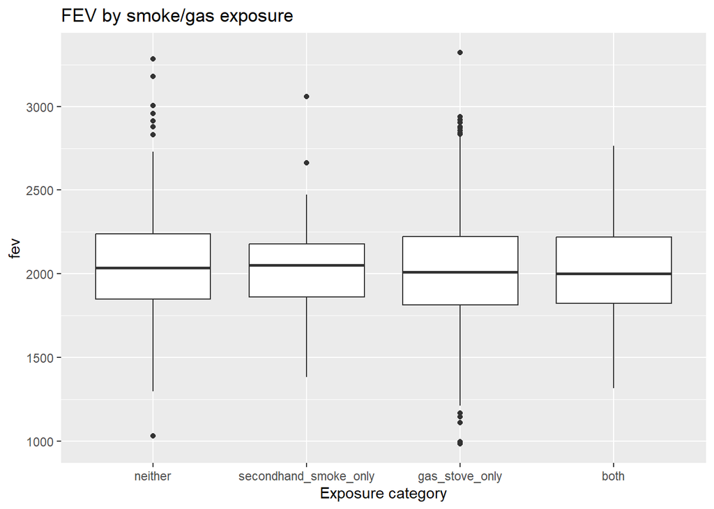

```r
df2 <- chs_imp %>%
  filter(!is.na(smoke_gas_exposure), !is.na(fev))

ggplot(df2, aes(x = smoke_gas_exposure, y = fev)) +
  geom_boxplot() +
  labs(title = "FEV by smoke/gas exposure", x = "Exposure category")
```

```r
df2 %>%
  group_by(smoke_gas_exposure) %>%
  summarise(mean_fev = mean(fev), sd_fev = sd(fev), n = n(), .groups = "drop")
```

```
# A tibble: 4 × 4
  smoke_gas_exposure    mean_fev sd_fev     n
  <fct>                    <dbl>  <dbl> <int>
1 neither                  2057.   329.   219
2 secondhand_smoke_only    2056.   296.    36
3 gas_stove_only           2023.   319.   791
4 both                     2025.   301.   154
```

```r
# Challenge (adjust for sex/height/age)
raw_tab <- df2 %>%
  group_by(smoke_gas_exposure) %>%
  summarise(
    mean_fev = mean(fev),
    sd_fev = sd(fev),
    n = n(),
    .groups = "drop"
  )

m2_adj <- lm(fev ~ smoke_gas_exposure + male + height + agepft, data = df2)
summary(m2_adj)
```

```
Call:
lm(formula = fev ~ smoke_gas_exposure + male + height + agepft,
    data = df2)

Residuals:
     Min       1Q   Median       3Q      Max
-1011.10  -135.59     4.03   139.28   999.84

Coefficients:
                                         Estimate Std. Error t value Pr(>|t|)
(Intercept)                             -2370.109    196.439 -12.065   <2e-16
smoke_gas_exposuresecondhand_smoke_only   -19.439     41.913  -0.464    0.643
smoke_gas_exposuregas_stove_only           -2.053     17.833  -0.115    0.908
smoke_gas_exposureboth                    -21.271     24.542  -0.867    0.386
male                                      125.901     13.568   9.279   <2e-16
height                                     31.677      1.073  29.516   <2e-16
agepft                                     -5.925     16.904  -0.350    0.726

(Intercept)                             ***
smoke_gas_exposuresecondhand_smoke_only
smoke_gas_exposuregas_stove_only
smoke_gas_exposureboth
male                                    ***
height                                  ***
agepft
---
Signif. codes:  0 '***' 0.001 '**' 0.01 '*' 0.05 '.' 0.1 ' ' 1

Residual standard error: 232.9 on 1193 degrees of freedom
Multiple R-squared:  0.4661,    Adjusted R-squared:  0.4634
F-statistic: 173.6 on 6 and 1193 DF,  p-value: < 2.2e-16
```

```r
library(emmeans)
adj_tab <- emmeans(m2_adj, ~ smoke_gas_exposure)
adj_tab
```

```
 smoke_gas_exposure    emmean    SE   df lower.CL upper.CL
 neither                 2036 15.80 1193     2005     2067
 secondhand_smoke_only   2016 38.90 1193     1940     2093
 gas_stove_only          2034  8.29 1193     2018     2050
 both                    2015 18.80 1193     1978     2051

Results are averaged over the levels of: male
Confidence level used: 0.95
```

```r
adj_diff <- contrast(adj_tab, method = "trt.vs.ctrl", ref = "neither")
adj_diff
```

```
 contrast                        estimate   SE   df t.ratio p.value
 secondhand_smoke_only - neither   -19.44 41.9 1193  -0.464  0.9103
 gas_stove_only - neither           -2.05 17.8 1193  -0.115  0.9949
 both - neither                    -21.27 24.5 1193  -0.867  0.6972

Results are averaged over the levels of: male
P value adjustment: dunnettx method for 3 tests
```

```r
raw_only <- raw_tab %>%
  select(smoke_gas_exposure, raw_mean = mean_fev, raw_sd = sd_fev, n)

adj_only <- as.data.frame(adj_tab) %>%
  select(smoke_gas_exposure, adj_mean = emmean, adj_se = SE, df)

comparison <- left_join(raw_only, adj_only, by = "smoke_gas_exposure")
comparison
```

```
# A tibble: 4 × 7
  smoke_gas_exposure    raw_mean raw_sd     n adj_mean adj_se    df
  <fct>                    <dbl>  <dbl> <int>    <dbl>  <dbl> <dbl>
1 neither                  2057.   329.   219    2036.  15.8   1193
2 secondhand_smoke_only    2056.   296.    36    2016.  38.9   1193
3 gas_stove_only           2023.   319.   791    2034.   8.29  1193
4 both                     2025.   301.   154    2015.  18.8   1193
```

In unadjusted comparisons, mean FEV was ~30–35 ml lower in the gas-stove-only and both-exposure groups compared with neither exposure.

Height and sex were strongly associated with FEV, suggesting the crude differences largely reflected differences in body size/sex composition across exposure groups rather than a clear exposure effect.

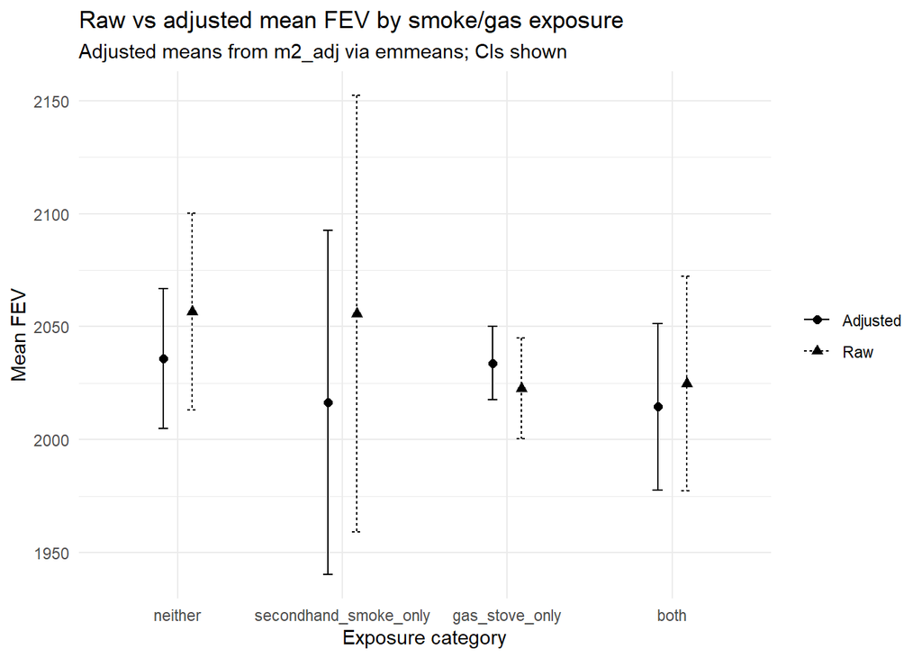

```r
df2_sum <- df2 %>%
  group_by(smoke_gas_exposure) %>%
  summarise(
    raw_mean = mean(.data[["fev"]], na.rm = TRUE),
    raw_sd   = sd(.data[["fev"]], na.rm = TRUE),
    n = n(),
    .groups = "drop"
  ) %>%
  mutate(raw_se = raw_sd / sqrt(n),
         raw_ci_lo = raw_mean - 1.96 * raw_se,
         raw_ci_hi = raw_mean + 1.96 * raw_se)

adj_df <- as.data.frame(adj_tab) %>%
  mutate(
    adj_ci_lo = emmean - qt(0.975, df) * SE,
    adj_ci_hi = emmean + qt(0.975, df) * SE
  ) %>%
  transmute(
    smoke_gas_exposure,
    adj_mean = emmean,
    adj_ci_lo,
    adj_ci_hi
  )

means_both <- df2_sum %>%
  select(smoke_gas_exposure, raw_mean, raw_ci_lo, raw_ci_hi) %>%
  left_join(adj_df, by = "smoke_gas_exposure") %>%
  tidyr::pivot_longer(
    cols = c(raw_mean, adj_mean),
    names_to = "type",
    values_to = "mean"
  ) %>%
  mutate(
    type = recode(type, raw_mean = "Raw", adj_mean = "Adjusted"),
    ci_lo = if_else(type == "Raw", raw_ci_lo, adj_ci_lo),
    ci_hi = if_else(type == "Raw", raw_ci_hi, adj_ci_hi)
  )

ggplot(means_both, aes(x = smoke_gas_exposure, y = mean, group = type)) +
  geom_point(aes(shape = type), position = position_dodge(width = 0.35), size = 2) +
  geom_errorbar(
    aes(ymin = ci_lo, ymax = ci_hi, linetype = type),
    position = position_dodge(width = 0.35),
    width = 0.12
  ) +
  labs(
    title = "Raw vs adjusted mean FEV by smoke/gas exposure",
    subtitle = "Adjusted means from m2_adj via emmeans; CIs shown",
    x = "Exposure category",
    y = "Mean FEV",
    shape = NULL,
    linetype = NULL
  ) +
  theme_minimal()
```

The grouped scatterplot above compares simple (raw) mean FEV by smoke/gas exposure group to regression-adjusted mean FEV after controlling for sex, height, and age, with 95% confidence intervals. Overall, the raw means are fairly similar across categories and the adjusted means shift only slightly (most noticeably for the secondhand-smoke-only group), but in both cases the confidence intervals overlap substantially. This suggests differences in average FEV across exposure groups are modest relative to within-group variability, and covariate adjustment does not produce a dramatic separation between categories.

### Q3: Association between PM2.5 exposure and FEV

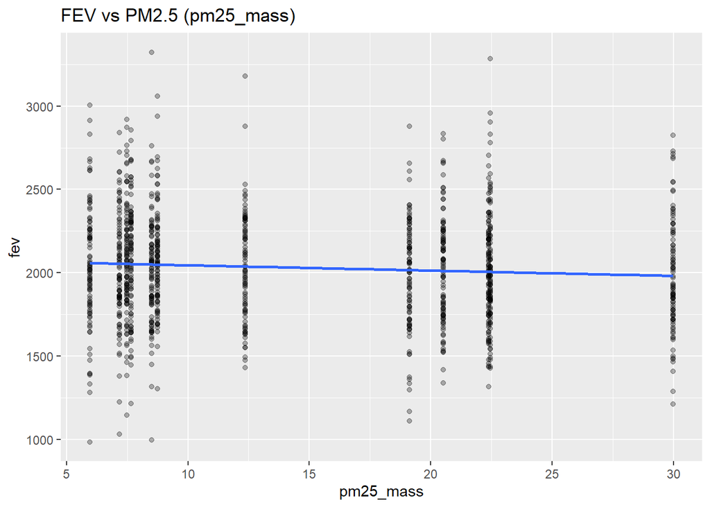

```r
df3 <- chs %>% filter(!is.na(pm25_mass), !is.na(fev))

ggplot(df3, aes(x = pm25_mass, y = fev)) +
  geom_point(alpha = 0.3) +
  geom_smooth(method = "lm", se = FALSE) +
  labs(title = "FEV vs PM2.5 (pm25_mass)")
```

```r
m3_easy <- lm(fev ~ pm25_mass, data = df3)
summary(m3_easy)
```

```
Call:
lm(formula = fev ~ pm25_mass, data = df3)

Residuals:
     Min       1Q   Median       3Q      Max
-1073.46  -224.99    -7.52   213.52  1277.68

Coefficients:
            Estimate Std. Error t value Pr(>|t|)
(Intercept) 2077.317     21.000  98.922   <2e-16 ***
pm25_mass     -3.189      1.282  -2.488    0.013 *
---
Signif. codes:  0 '***' 0.001 '**' 0.01 '*' 0.05 '.' 0.1 ' ' 1

Residual standard error: 329.9 on 1103 degrees of freedom
Multiple R-squared:  0.005583,  Adjusted R-squared:  0.004681
F-statistic: 6.192 on 1 and 1103 DF,  p-value: 0.01298
```

```r
m3_adj <- lm(fev ~ pm25_mass + male + height + agepft, data = df3)
summary(m3_adj)
```

```
Call:
lm(formula = fev ~ pm25_mass + male + height + agepft, data = df3)

Residuals:
    Min      1Q  Median      3Q     Max
-994.73 -148.80   10.95  155.82 1019.66

Coefficients:
              Estimate Std. Error t value Pr(>|t|)
(Intercept) -2317.8960   207.5833 -11.166   <2e-16 ***
pm25_mass      -1.6473     0.9521  -1.730   0.0839 .
male          124.6853    14.6269   8.524   <2e-16 ***
height         31.9878     1.1149  28.691   <2e-16 ***
agepft        -13.5594    17.7876  -0.762   0.4460
---
Signif. codes:  0 '***' 0.001 '**' 0.01 '*' 0.05 '.' 0.1 ' ' 1

Residual standard error: 241.3 on 1100 degrees of freedom
Multiple R-squared:  0.4694,    Adjusted R-squared:  0.4674
F-statistic: 243.2 on 4 and 1100 DF,  p-value: < 2.2e-16
```

In the easy (unadjusted) model, PM2.5 mass is negatively associated with lung function: each 1-unit increase in pm25_mass is associated with about 3.19 ml lower FEV (p = 0.013). However, this model explains essentially none of the variability in FEV (R^2 ≈ 0.006), meaning PM2.5 alone is a very weak predictor at the individual level.

In the challenged (adjusted) model controlling for sex, height, and age, the PM2.5 association becomes smaller in magnitude (about −1.65 ml per unit) and is only marginal (p = 0.084), suggesting the crude association was at least partly confounded by differences in body size/sex/age across towns. Meanwhile, the adjustment variables behave as expected and dominate prediction: height (~+32 ml per unit) and male sex (~+125 ml) are strongly associated with higher FEV, and the model’s R^2 jumps to ~0.47 largely due to these physiological predictors rather than PM2.

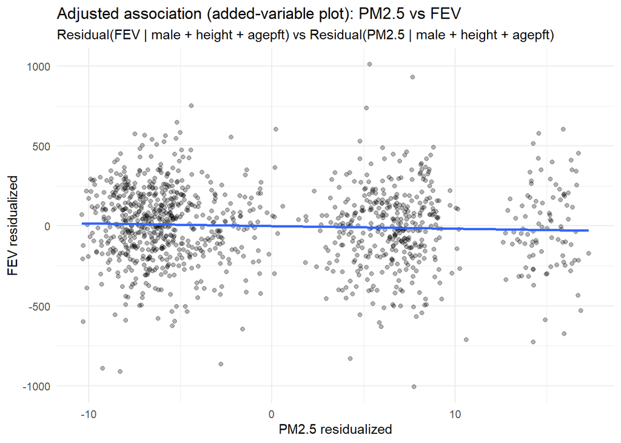

```r
df3_plot <- df3 %>%
  mutate(
    pm25_resid = resid(lm(pm25_mass ~ male + height + agepft, data = df3)),
    fev_resid  = resid(lm(fev ~ male + height + agepft, data = df3))
  )

ggplot(df3_plot, aes(x = pm25_resid, y = fev_resid)) +
  geom_point(alpha = 0.3) +
  geom_smooth(method = "lm", se = FALSE) +
  labs(
    title = "Adjusted association (added-variable plot): PM2.5 vs FEV",
    subtitle = "Residual(FEV | male + height + agepft) vs Residual(PM2.5 | male + height + agepft)",
    x = "PM2.5 residualized",
    y = "FEV residualized"
  ) +
  theme_minimal()
```

This added-variable (partial regression) plot shows the relationship between PM2.5 and FEV after removing the effects of sex, height, and age from both variables: the x-axis is the residualized PM2.5 (variation not explained by male/height/agepft) and the y-axis is the residualized FEV. Just like the plot of the original variables, the fitted line is essentially flat with only a very slight downward tilt, indicating that once those physiological covariates are accounted for, PM2.5 still has little independent linear association with FEV in this dataset. The wide scatter around the line reinforces that the remaining PM2.5 signal is small relative to the residual variability in FEV, consistent with a weak and possibly non-significant adjusted effect.

# 3. Data visualizations

## (i) Facet plot showing scatterplots with regression lines of BMI vs FEV by “townname”

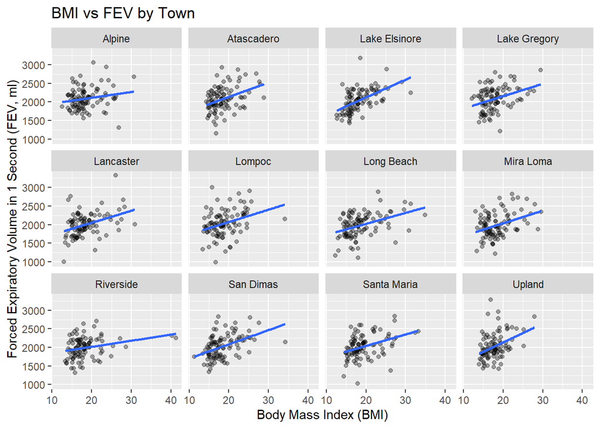

```r
library(dplyr)
library(ggplot2)

df_bmi_fev <- chs_imp %>%
  filter(!is.na(bmi), !is.na(fev), !is.na(townname))

ggplot(df_bmi_fev, aes(x = bmi, y = fev)) +
  geom_point(alpha = 0.35) +
  geom_smooth(method = "lm", se = FALSE) +
  facet_wrap(~ townname) +
  labs(
    title = "BMI vs FEV by Town",
    x = "Body Mass Index (BMI)",
    y = "Forced Expiratory Volume in 1 Second (FEV, ml)"
  )
```

Across all 12 towns, the regression line slopes are positive, meaning higher BMI tends to be associated with higher FEV within each town. The strength of the relationship varies: some towns (e.g., Lake Elsinore, San Dimas, Upland) show a steeper upward trend, while others (e.g., Riverside, Alpine) look flatter, suggesting a weaker within-town BMI–FEV association there. In every panel, there’s also substantial scatter around the line, so BMI alone doesn’t explain most of the person-to-person variation in FEV within a town. Finally, the cloud of points shifts up/down across towns, implying that towns differ in average FEV levels (possibly due to differences in age/height/sex composition or other town-level factors), even though the within-town BMI–FEV trend is generally consistent.

## (ii) Stacked histograms of FEV by BMI category and FEV by smoke/gas exposure

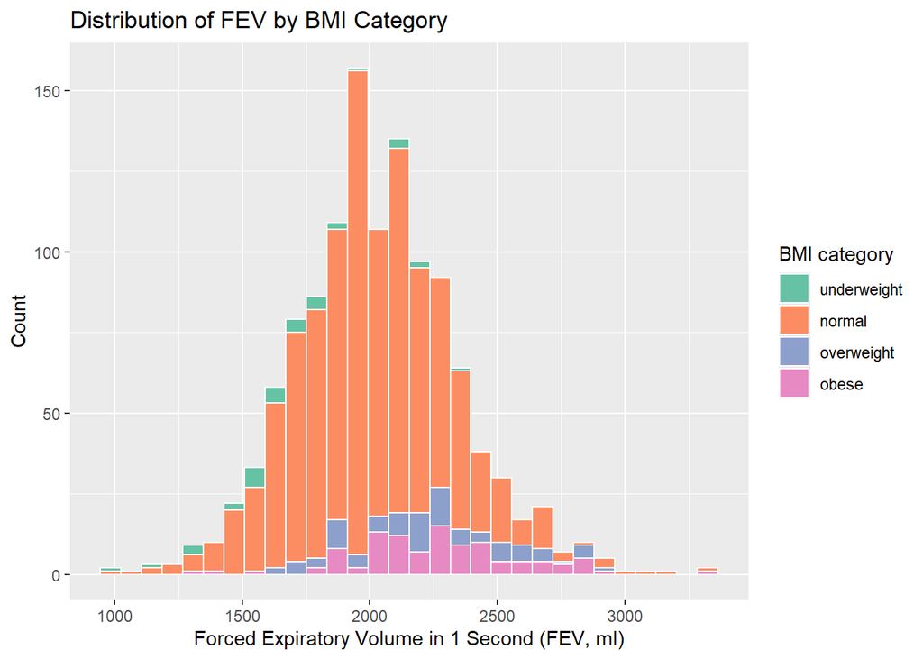

```r
library(dplyr)
library(ggplot2)

df_plot <- chs_imp %>%
  filter(!is.na(fev))

# 1) Stacked histogram: FEV by BMI category (obesity_level)
ggplot(df_plot %>% filter(!is.na(obesity_level)),
       aes(x = fev, fill = obesity_level)) +
  geom_histogram(position = "stack", bins = 30, color = "white") +
  scale_fill_brewer(palette = "Set2", name = "BMI category") +
  labs(
    title = "Distribution of FEV by BMI Category",
    x = "Forced Expiratory Volume in 1 Second (FEV, ml)",
    y = "Count"
  )
```

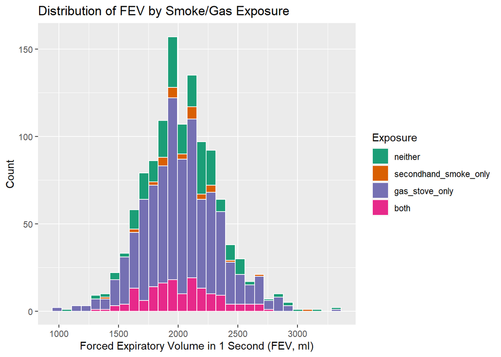

```r
# 2) Stacked histogram: FEV by smoke/gas exposure
ggplot(df_plot %>% filter(!is.na(smoke_gas_exposure)),
       aes(x = fev, fill = smoke_gas_exposure)) +
  geom_histogram(position = "stack", bins = 30, color = "white") +
  scale_fill_brewer(palette = "Dark2", name = "Exposure") +
  labs(
    title = "Distribution of FEV by Smoke/Gas Exposure",
    x = "Forced Expiratory Volume in 1 Second (FEV, ml)",
    y = "Count"
  )
```

FEV is roughly unimodal, BMI is right-skewed with a few high outliers, and PM2.5 appears in discrete spikes because it’s measured at the town level and repeats across children within towns. BMI is positively associated with FEV, but the effect shrinks after adjusting for sex/height/age, indicating much of the raw association reflects body size. Smoke/gas exposure groups have very similar FEV distributions and show no clear adjusted differences from the “neither” group. PM2.5 has a small negative unadjusted association with FEV that weakens after adjustment, so any effect looks modest relative to individual variability.

## (iii) Barchart of BMI by smoke/gas exposure

```r
library(dplyr)
library(ggplot2)

df_bmi_exposure <- chs_imp %>%
  filter(!is.na(bmi), !is.na(smoke_gas_exposure))

# Bar chart of mean BMI by exposure (with SE error bars)
bmi_sum <- df_bmi_exposure %>%
  group_by(smoke_gas_exposure) %>%
  summarise(
    mean_bmi = mean(bmi),
    sd_bmi = sd(bmi),
    n = n(),
    se_bmi = sd_bmi / sqrt(n),
    .groups = "drop"
  )

bmi_sum
```

```
# A tibble: 4 × 5
  smoke_gas_exposure    mean_bmi sd_bmi     n se_bmi
  <fct>                    <dbl>  <dbl> <int>  <dbl>
1 neither                   18.2   3.37   219  0.228
2 secondhand_smoke_only     19.2   3.38    36  0.564
3 gas_stove_only            18.4   3.65   791  0.130
4 both                      19.1   3.94   154  0.317
```

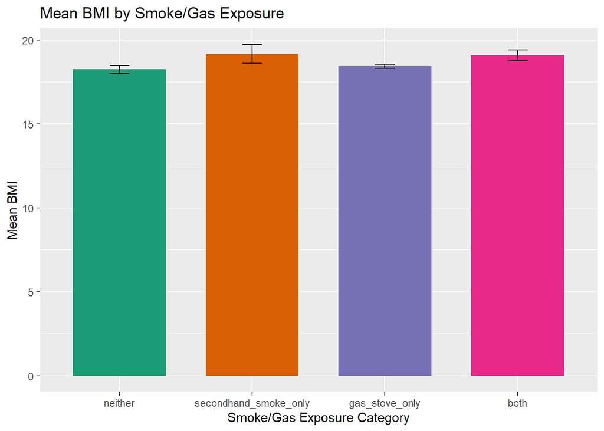

```r
ggplot(bmi_sum, aes(x = smoke_gas_exposure, y = mean_bmi, fill = smoke_gas_exposure)) +
  geom_col(width = 0.7) +
  geom_errorbar(aes(ymin = mean_bmi - se_bmi, ymax = mean_bmi + se_bmi), width = 0.15) +
  scale_fill_brewer(palette = "Dark2", guide = "none") +
  labs(
    title = "Mean BMI by Smoke/Gas Exposure",
    x = "Smoke/Gas Exposure Category",
    y = "Mean BMI"
  )
```

## (iv) Statistical summary graphs of FEV by BMI and FEV by smoke/gas exposure category

```r
library(dplyr)
library(ggplot2)

df <- chs_imp %>%
  filter(!is.na(fev))

# 1) Statistical summary: FEV by BMI category (mean + SE)
sum_bmi <- df %>%
  filter(!is.na(obesity_level)) %>%
  group_by(obesity_level) %>%
  summarise(
    mean_fev = mean(fev),
    sd_fev = sd(fev),
    n = n(),
    se_fev = sd_fev / sqrt(n),
    .groups = "drop"
  )

sum_bmi
```

```
# A tibble: 4 × 5
  obesity_level mean_fev sd_fev     n se_fev
  <fct>            <dbl>  <dbl> <int>  <dbl>
1 underweight      1698.   303.    35  51.3
2 normal           2000.   295.   975   9.45
3 overweight       2224.   317.    87  34.0
4 obese            2266.   325.   103  32.1
```

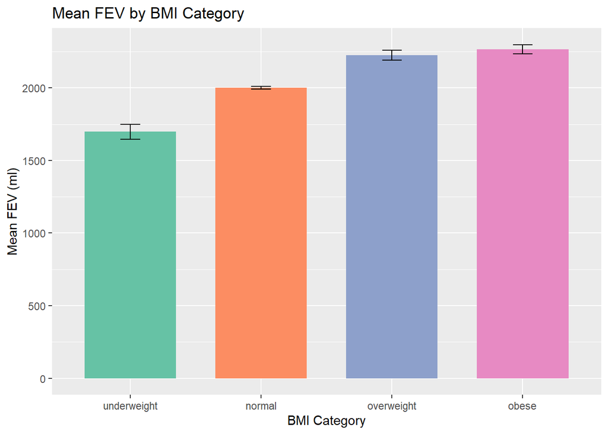

```r
ggplot(sum_bmi, aes(x = obesity_level, y = mean_fev, fill = obesity_level)) +
  geom_col(width = 0.7) +
  geom_errorbar(aes(ymin = mean_fev - se_fev, ymax = mean_fev + se_fev), width = 0.15) +
  scale_fill_brewer(palette = "Set2", guide = "none") +
  labs(
    title = "Mean FEV by BMI Category",
    x = "BMI Category",
    y = "Mean FEV (ml)"
  )
```

```r
# 2) Statistical summary: FEV by smoke/gas exposure (mean + SE)
sum_exposure <- df %>%
  filter(!is.na(smoke_gas_exposure)) %>%
  group_by(smoke_gas_exposure) %>%
  summarise(
    mean_fev = mean(fev),
    sd_fev = sd(fev),
    n = n(),
    se_fev = sd_fev / sqrt(n),
    .groups = "drop"
  )

sum_exposure
```

```
# A tibble: 4 × 5
  smoke_gas_exposure    mean_fev sd_fev     n se_fev
  <fct>                    <dbl>  <dbl> <int>  <dbl>
1 neither                  2057.   329.   219   22.2
2 secondhand_smoke_only    2056.   296.    36   49.3
3 gas_stove_only           2023.   319.   791   11.4
4 both                     2025.   301.   154   24.2
```

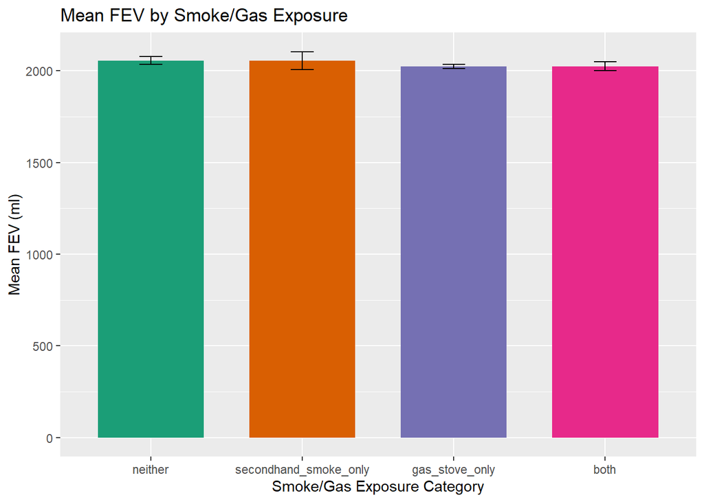

```r
ggplot(sum_exposure, aes(x = smoke_gas_exposure, y = mean_fev, fill = smoke_gas_exposure)) +
  geom_col(width = 0.7) +
  geom_errorbar(aes(ymin = mean_fev - se_fev, ymax = mean_fev + se_fev), width = 0.15) +
  scale_fill_brewer(palette = "Dark2", guide = "none") +
  labs(
    title = "Mean FEV by Smoke/Gas Exposure",
    x = "Smoke/Gas Exposure Category",
    y = "Mean FEV (ml)"
  )
```

Mean FEV increases steadily across BMI categories, from lowest in the underweight group to highest in the overweight/obese groups, suggesting a clear positive association between body size and lung volume. The error bars are small relative to the differences between BMI groups, so this trend looks consistent. In contrast, mean FEV is very similar across the four smoke/gas exposure categories, with only small differences and largely overlapping error bars. Overall, BMI category shows a much stronger relationship with FEV than smoke/gas exposure does in these summaries.

## (v) A leaflet map showing the concentrations of PM2.5 mass in each of the CHS communities

```r
library(dplyr)
library(leaflet)

chs_regional <- read.csv("chs_regional.csv")
head(chs_regional)
```

```
       townname pm25_mass pm25_so4 pm25_no3 pm25_nh4 pm25_oc pm25_ec pm25_om
1        Alpine      8.74     1.73     1.59     0.88    2.54    0.48    3.04
2 Lake Elsinore     12.35     1.90     2.98     1.36    3.64    0.62    4.36
3  Lake Gregory      7.66     1.07     2.07     0.91    2.46    0.40    2.96
4     Lancaster      8.50     0.91     1.87     0.78    4.43    0.55    5.32
5        Lompoc      5.96     1.08     0.73     0.41    1.45    0.13    1.74
6    Long Beach     19.12     3.23     6.22     2.57    5.21    1.36    6.25
  pm10_oc pm10_ec pm10_tc formic acetic  hcl hno3 o3_max o3106 o3_24   no2
1    3.25    0.49    3.75   1.03   2.49 0.41 1.98  65.82 55.05 41.23 12.18
2    4.66    0.63    5.29   1.18   3.56 0.46 2.63  66.70 54.42 32.23 17.03
3    3.16    0.41    3.57   0.66   2.36 0.28 2.28  84.44 67.01 57.76  7.62
4    5.68    0.56    8.61   0.88   2.88 0.22 1.80  54.81 43.88 32.86 15.77
5    1.86    0.14    1.99   0.34   0.75 0.33 0.43  43.85 37.74 28.37  4.60
6    6.68    1.39    8.07   1.57   2.94 0.73 2.67  39.44 28.22 18.22 33.11
   pm10 no_24hr pm2_5_fr iacid oacid total_acids       lon      lat
1 24.73    2.48    10.28  2.39  3.52        5.50 -116.7664 32.83505
2 34.25    7.07    14.53  3.09  4.74        7.37 -117.3273 33.66808
3 20.05      NA     9.01  2.56  3.02        5.30 -117.2752 34.24290
4 25.04   12.68       NA  2.02  3.76        5.56 -118.1542 34.68678
5 18.40    2.05       NA  0.76  1.09        1.52 -120.4579 34.63915
6 38.41   36.76    22.23  3.40  4.51        7.18 -118.1937 33.77005
```

```r
names(chs_regional)
```

```
 [1] "townname"    "pm25_mass"   "pm25_so4"    "pm25_no3"    "pm25_nh4"
 [6] "pm25_oc"     "pm25_ec"     "pm25_om"     "pm10_oc"     "pm10_ec"
[11] "pm10_tc"     "formic"      "acetic"      "hcl"         "hno3"
[16] "o3_max"      "o3106"       "o3_24"       "no2"         "pm10"
[21] "no_24hr"     "pm2_5_fr"    "iacid"       "oacid"       "total_acids"
[26] "lon"         "lat"
```

```r
# PM2.5 mass column
pm_var <- "pm25_mass"

# Quick check
chs_regional %>%
  select(townname, all_of("lat"), all_of("lon"), all_of(pm_var)) %>%
  head()
```

```
       townname      lat       lon pm25_mass
1        Alpine 32.83505 -116.7664      8.74
2 Lake Elsinore 33.66808 -117.3273     12.35
3  Lake Gregory 34.24290 -117.2752      7.66
4     Lancaster 34.68678 -118.1542      8.50
5        Lompoc 34.63915 -120.4579      5.96
6    Long Beach 33.77005 -118.1937     19.12
```

```r
pal <- colorNumeric(palette = "viridis", domain = chs_regional[[pm_var]])

leaflet(chs_regional) %>%
  addProviderTiles(providers$CartoDB.Positron) %>%
  addCircleMarkers(
    lng = ~lon,
    lat = ~lat,
    fillColor = ~pal(pm25_mass),
    fillOpacity = 0.9,
    radius = 7,
    stroke = TRUE,
    weight = 1,
    color = "white",
    popup = ~paste0("<b>", townname, "</b><br>PM2.5 mass: ", round(pm25_mass, 2))
  ) %>%
  addLegend("bottomright", pal = pal, values = ~pm25_mass, title = "PM2.5 mass")
```

[interactive chart not shown]

## (vi) Choose a visualization to examine whether PM2.5 mass is associated with FEV

```r
library(dplyr)
library(ggplot2)

df3 <- chs_imp %>%
  filter(!is.na(fev), !is.na(pm25_mass), !is.na(townname))

# (Recommended) Town-level visualization:
# Plot the mean FEV in each town vs the town’s PM2.5, with a regression line.
town_summary <- df3 %>%
  group_by(townname, pm25_mass) %>%
  summarise(
    mean_fev = mean(fev),
    n = n(),
    .groups = "drop"
  )

town_summary
```

```
# A tibble: 12 × 4
   townname      pm25_mass mean_fev     n
   <chr>             <dbl>    <dbl> <int>
 1 Alpine             8.74    2087.   100
 2 Atascadero         7.48    2076.   100
 3 Lake Elsinore     12.4     2039.   100
 4 Lake Gregory       7.66    2085.   100
 5 Lancaster          8.5     2003.   100
 6 Lompoc             5.96    2034.   100
 7 Long Beach        19.1     1986.   100
 8 Mira Loma         30.0     1985.   100
 9 Riverside         22.4     1990.   100
10 San Dimas         20.5     2027.   100
11 Santa Maria        7.19    2026.   100
12 Upland            22.5     2024.   100
```

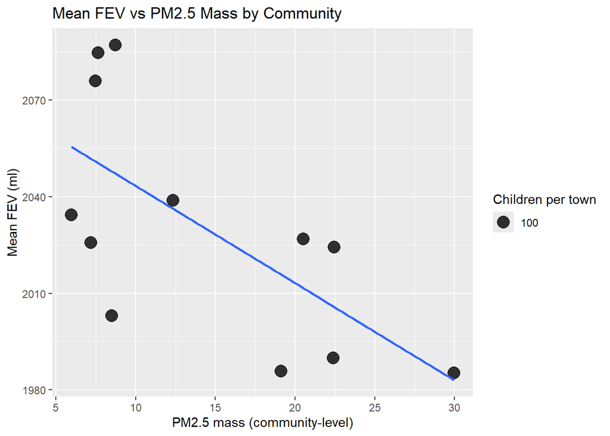

```r
ggplot(town_summary, aes(x = pm25_mass, y = mean_fev)) +
  geom_point(aes(size = n), alpha = 0.8) +
  geom_smooth(method = "lm", se = FALSE) +
  labs(
    title = "Mean FEV vs PM2.5 Mass by Community",
    x = "PM2.5 mass (community-level)",
    y = "Mean FEV (ml)",
    size = "Children per town"
  )
```

This community-level plot shows a negative association between PM2.5 mass and mean FEV: towns with higher PM2.5 tend to have lower average FEV, as indicated by the downward regression line. However, there is noticeable scatter around the line, so PM2.5 alone does not perfectly explain differences in mean FEV across towns. Because each point represents a town average (with size reflecting the number of children), the pattern reflects between-community differences rather than individual-level variation. Overall, the figure is consistent with a modest adverse relationship between PM2.5 exposure and lung function in this dataset.